# EU Omnibus Briefing

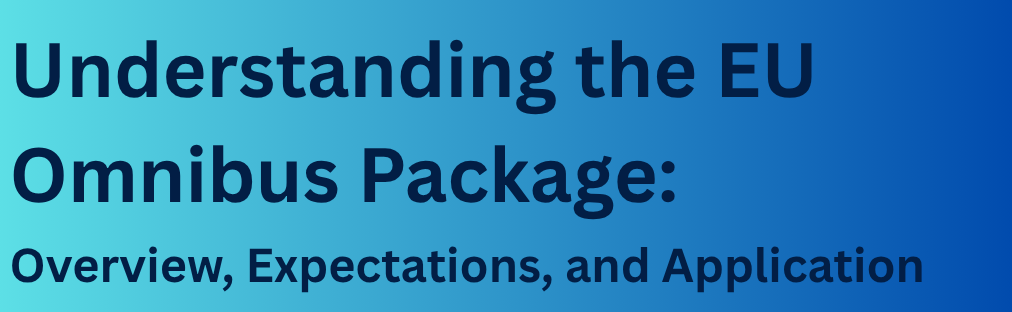

The Omnibus Package marks one of the first legislative steps toward reducing regulatory burdens within the EU. In the Budapest Declaration on the New European Competitiveness Deal, EU Heads of State and Government called for a “simplification revolution” aimed at creating a clear, streamlined, and business-friendly regulatory framework, with a particular focus on easing administrative, regulatory, and reporting burdens for SMEs. This initiative is driven by the broader goal of enhancing the competitiveness and resilience of EU businesses amid rapid global change and ongoing uncertainty linked to the Russia-Ukraine war.

Against this backdrop, this report presents a comprehensive analysis of the EU Omnibus Package, drawing on detailed research to evaluate the potential impacts on both existing and prospective clients. As the regulatory environment within the European Union continues to evolve at a rapid pace, it is increasingly evident that the ability of clients to successfully navigate this complex and shifting landscape is becoming a crucial concern. The findings outlined here aim to highlight areas of change, anticipate emerging challenges, and help clients respond effectively to upcoming legislative developments.

Below is a summary of the key legislations that will be affected by the EU Omnibus Package:

An EU directive adopted on 28 November 2022, which revises several existing directives and regulations, including the Accounting Directive, Transparency Directive, Audit Directive, and Audit Regulation. The CSRD aims to improve the quality, consistency, and comparability of sustainability information disclosed by companies. Its primary goal is to provide investors and stakeholders with reliable data to assess and manage sustainability-related risks, especially those arising from climate change and social/environmental impacts. It also enforces double materiality, meaning companies must report both on how sustainability issues affect them and how their operations impact society and the environment.

An EU directive adopted on 24 April 2024, which requires certain large EU and non-EU companies to identify, prevent, mitigate, and account for adverse human rights and environmental impacts in their operations, subsidiaries, and value chains. The CSDDD introduces due diligence obligations, encouraging responsible business conduct throughout the supply chain, and includes provisions for climate transition planning aligned with the Paris Agreement.

Adopted on 18 June 2020, this framework was developed by the European Union to establish a classification system for environmentally sustainable economic activities. Its primary purpose is to direct investments toward initiatives that align with the EU’s climate and environmental goals, particularly the ambition of achieving climate neutrality by 2050. By providing sector-specific guidelines, the taxonomy helps investors, companies, and policymakers make well-informed, sustainable choices. These are the current steps for companies to report under EU Taxonomy.

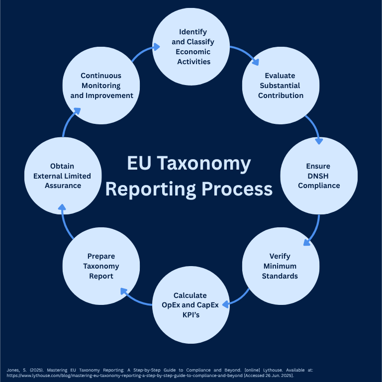

Companies must align their activities with six environmental objectives and ensure they meet the “Do No Significant Harm” (DNSH) criteria, which means their activities must not significantly harm any of these objectives.

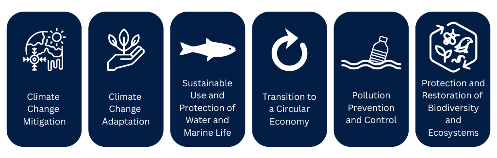

A policy initiative adopted by the EU on 10 May 2023 aimed at preventing carbon leakage and promoting fair, sustainable trade. It imposes a carbon charge on certain imports from countries with generally less stringent climate policies, ensuring that imported goods meet environmental standards comparable to those within the EU.